# Movies_Reviews_Sentiment_Analysis_v6

## About Dataset

The dataset is comprised of tab-separated files with phrases from the Rotten Tomatoes dataset. The train/test split has been preserved for the purposes of benchmarking, but the sentences have been shuffled from their original order. Each Sentence has been parsed into many phrases by the Stanford parser. Each phrase has a PhraseId. Each sentence has a SentenceId. Phrases that are repeated (such as short/common words) are only included once in the data.

data.tsv contains the phrases and their associated sentiment labels. We have additionally provided a SentenceId so that you can track which phrases belong to a single sentence.

The sentiment labels are:

0 - negative

1 - somewhat negative

2 - neutral

3 - somewhat positive

4 - positive

### Target -

#### For a problem statement:

> - Data exploration
> - Data visualization
> - Data pre-processing/ Feature Engineering
> - Apply a few machine learning algorithms
> - Evaluation of results
> - Interesting Findings

### Importing the basic libraries

```python
import pandas as pd # data processing, CSV file I/O (e.g. pd.read_csv)
pd.set_option('display.max_rows', 500)
pd.set_option('display.max_columns', 500)
pd.set_option('display.width', 1000)
import numpy as np
import warnings
warnings.filterwarnings("ignore")

from sklearn.feature_extraction.text import TfidfVectorizer
from sklearn.feature_extraction.text import CountVectorizer

import regex as re
import csv
from bs4 import BeautifulSoup

import seaborn as sns
from termcolor import colored
import matplotlib.pyplot as plt
%matplotlib inline

# The Natural Language Toolkit, or more commonly NLTK, is a suite of libraries and programs for symbolic and
# statistical natural language processing for English written in the Python programming language

import nltk
from nltk.corpus import stopwords
from nltk import wordpunct_tokenize
from nltk import word_tokenize
from nltk.util import ngrams
import collections
from collections import Counter
from sklearn.feature_extraction import text
```

```python
data = pd.read_csv('data.tsv', sep="\t")
```

```python
data.head()
```

|  | PhraseId | SentenceId | Phrase | Sentiment |
| --- | --- | --- | --- | --- |
| 0 | 1 | 1 | A series of escapades demonstrating the adage ... | 1 |
| 1 | 2 | 1 | A series of escapades demonstrating the adage ... | 2 |
| 2 | 3 | 1 | A series | 2 |
| 3 | 4 | 1 | A | 2 |
| 4 | 5 | 1 | series | 2 |

```python
data.info()
```

```
<class 'pandas.core.frame.DataFrame'>
RangeIndex: 156060 entries, 0 to 156059
Data columns (total 4 columns):
PhraseId      156060 non-null int64
SentenceId    156060 non-null int64
Phrase        156060 non-null object
Sentiment     156060 non-null int64
dtypes: int64(3), object(1)
memory usage: 4.8+ MB
```

```python
data.describe()
```

|  | PhraseId | SentenceId | Sentiment |
| --- | --- | --- | --- |
| count | 156060.000000 | 156060.000000 | 156060.000000 |
| mean | 78030.500000 | 4079.732744 | 2.063578 |
| std | 45050.785842 | 2502.764394 | 0.893832 |
| min | 1.000000 | 1.000000 | 0.000000 |
| 25% | 39015.750000 | 1861.750000 | 2.000000 |
| 50% | 78030.500000 | 4017.000000 | 2.000000 |
| 75% | 117045.250000 | 6244.000000 | 3.000000 |
| max | 156060.000000 | 8544.000000 | 4.000000 |

```python
data.Sentiment.nunique()
```

```
5
```

```python
# Count of reviews by sentiment
data.groupby('Sentiment')['Sentiment'].value_counts()
```

```
Sentiment  Sentiment
0          0             7072
1          1            27273
2          2            79582
3          3            32927
4          4             9206
Name: Sentiment, dtype: int64
```

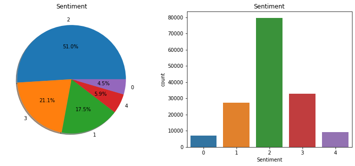

```python
#visualize the distribution of Sentiments
f,ax=plt.subplots(1,2,figsize=(13,5))
data['Sentiment'].value_counts().plot.pie(autopct='%1.1f%%',ax=ax[0],shadow=True)
ax[0].set_title('Sentiment')
ax[0].set_ylabel('')
sns.countplot('Sentiment',data=data,ax=ax[1])
ax[1].set_title('Sentiment')
plt.show()
```

> - We can obeserve that out of whole dataset half of sentiment is '`neutral`'.
> - Apart from sentiment '`neutral`' other sentiment '`somewhat negative`','`somewhat positive`' occupies around 17.5% and 21.1% respectively.

# Data Cleaning and Data Preparation

### Let's look for first few records in `'Phrase'` column.

```python
print(data.iloc[0:10,2].values)
```

```
['A series of escapades demonstrating the adage that what is good for the goose is also good for the gander , some of which occasionally amuses but none of which amounts to much of a story .'
 'A series of escapades demonstrating the adage that what is good for the goose'
 'A series' 'A' 'series'
 'of escapades demonstrating the adage that what is good for the goose'
 'of' 'escapades demonstrating the adage that what is good for the goose'
 'escapades' 'demonstrating the adage that what is good for the goose']
```

- ### From the above two results we can observe that there is need to cleaning the text columns.
- ## We need to perform below mentioned text cleaning steps.
> - a. Remove unwanted characters
> - b. Convert text to lowercase
> - c. Remove unwanted spaces
> - d. Remove stopwords

### Removing unwanted leading and trailing spaces in text column using strip() method.

```python
print('Before removing unwanted spaces : \n\n', colored(data.iloc[0,2], 'blue'))
```

```
Before removing unwanted spaces :

 A series of escapades demonstrating the adage that what is good for the goose is also good for the gander , some of which occasionally amuses but none of which amounts to much of a story .
```

```python
data['Clean_Phrase'] = data['Phrase'].apply(lambda x: x.strip())
```

```python
#Replace multiple spaces with single spaces
data["Clean_Phrase"] = data.Clean_Phrase.str.replace(' +',' ')
```

```python
data['Phrase'] = data['Clean_Phrase']
```

```python
print('After removing unwanted spaces\n\n', colored(data.iloc[0,4],'blue'))
```

```
After removing unwanted spaces

 A series of escapades demonstrating the adage that what is good for the goose is also good for the gander , some of which occasionally amuses but none of which amounts to much of a story .
```

### Removing unwanted characters in text column using regular expressions.

```python
import re
```

```python
print('Before removing unwanted spaces : \n\n', colored(data.iloc[0,2],'blue'))
```

```
Before removing unwanted spaces :

 A series of escapades demonstrating the adage that what is good for the goose is also good for the gander , some of which occasionally amuses but none of which amounts to much of a story .
```

```python
data['Clean_Phrase'] = data['Phrase'].apply(lambda x: re.sub('[^A-Za-z]+', ' ', x)) #re.sub('[^A-Za-z0-9 ]+', '', blog.iloc[0,6])
```

```python
data['Phrase'] = data['Clean_Phrase']
```

```python
print('After removing unwanted spaces :\n\n', colored(data.iloc[0,4],'blue'))
```

```
After removing unwanted spaces :

 A series of escapades demonstrating the adage that what is good for the goose is also good for the gander some of which occasionally amuses but none of which amounts to much of a story
```

### Converting text to lowercase using lower() method.

```python
print('Before making all characters to lower case : \n\n', colored(data.iloc[0,2],'blue'))
```

```
Before making all characters to lower case :

 A series of escapades demonstrating the adage that what is good for the goose is also good for the gander some of which occasionally amuses but none of which amounts to much of a story
```

```python
data['Clean_Phrase'] = data['Phrase'].apply(lambda x: x.lower())
```

```python
data['Phrase'] = data['Clean_Phrase']
```

```python
print('After making all characters to lower case : \n\n', colored(data.iloc[0,4],'blue'))
```

```
After making all characters to lower case :

 a series of escapades demonstrating the adage that what is good for the goose is also good for the gander some of which occasionally amuses but none of which amounts to much of a story
```

### Removing stopwords from text using package "NLTK".

```python
import nltk
from nltk.corpus import stopwords
nltk.download('stopwords')
```

```
True
```

```python
stopwords = nltk.corpus.stopwords.words('english')
```

```python
alpha = []
for c in range(97, 123):
    alpha.append(chr(c))
```

```python
print(stopwords)
```

```
['i', 'me', 'my', 'myself', 'we', 'our', 'ours', 'ourselves', 'you', "you're", "you've", "you'll", "you'd", 'your', 'yours', 'yourself', 'yourselves', 'he', 'him', 'his', 'himself', 'she', "she's", 'her', 'hers', 'herself', 'it', "it's", 'its', 'itself', 'they', 'them', 'their', 'theirs', 'themselve…
```

```python
stopwords.extend(alpha)
stopwords.extend(['none','also','much','mr','us','one','series','ca','n','wo','movie','movies','film','flick','series'])
```

> - Adding some own stopwords after analysing the '`Phrase`' column

```python
print(stopwords)
```

```
['i', 'me', 'my', 'myself', 'we', 'our', 'ours', 'ourselves', 'you', "you're", "you've", "you'll", "you'd", 'your', 'yours', 'yourself', 'yourselves', 'he', 'him', 'his', 'himself', 'she', "she's", 'her', 'hers', 'herself', 'it', "it's", 'its', 'itself', 'they', 'them', 'their', 'theirs', 'themselve…
```

```python
len(stopwords)
```

```
220
```

```python
print('Before removing stopwords : \n\n', colored(data.iloc[0,2],'blue'))
```

```
Before removing stopwords :

 a series of escapades demonstrating the adage that what is good for the goose is also good for the gander some of which occasionally amuses but none of which amounts to much of a story
```

```python
print('Length of text before removing stopwords :', len(data.iloc[0,2]))
```

```
Length of text before removing stopwords : 185
```

```python
from collections import Counter
#stop_words = stopwords.words('english')
stopwords_dict = Counter(stopwords)

data['Clean_Phrase'] = data['Phrase'].apply(lambda x: ' '.join([word for word in x.split() if word not in stopwords_dict]))
```

```python
print('After removing stopwords : \n\n', colored(data.iloc[0,4],'blue'))
```

```
After removing stopwords :

 escapades demonstrating adage good goose good gander occasionally amuses amounts story
```

```python
print('After removing stopwords : \n', data.iloc[3,4])
```

```
After removing stopwords :
```

```python
print('Length of text after removing stopwords : ', len(data.iloc[3,4]))
```

```
Length of text after removing stopwords :  0
```

```python
# Removing all the rows which are blank
data.drop(data[data['Clean_Phrase'] == ''].index,axis = 0, inplace = True)
```

```python
data[data['Clean_Phrase'].map(len) < 5][['Phrase','Clean_Phrase']]
```

|  | Phrase | Clean_Phrase |
| --- | --- | --- |
| 22 | good | good |
| 84 | even | even |
| 85 | fans | fans |
| 93 | work | work |
| 108 | hard | hard |
| ... | ... | ... |
| 155795 | a jar | jar |
| 155874 | at the cia | cia |
| 155875 | the cia | cia |
| 155910 | how bad it is | bad |
| 155913 | zero | zero |

6252 rows × 2 columns

```python
data.drop(data[data['Clean_Phrase'].map(len) < 4].index,axis = 0,inplace = True)
```

> - Removing records which are having one review of only 3 or less than 3 characters as they are irrelevant reviews

```python
data[data['Clean_Phrase'].map(len) < 5][['Phrase','Clean_Phrase']]
```

|  | Phrase | Clean_Phrase |
| --- | --- | --- |
| 22 | good | good |
| 84 | even | even |
| 85 | fans | fans |
| 93 | work | work |
| 108 | hard | hard |
| ... | ... | ... |
| 155573 | s the kind of movie | kind |
| 155601 | taxi | taxi |
| 155661 | hazy | hazy |
| 155752 | the hand | hand |
| 155913 | zero | zero |

4515 rows × 2 columns

```python
data.info()
```

```
<class 'pandas.core.frame.DataFrame'>
Int64Index: 152282 entries, 0 to 156059
Data columns (total 5 columns):
PhraseId        152282 non-null int64
SentenceId      152282 non-null int64
Phrase          152282 non-null object
Sentiment       152282 non-null int64
Clean_Phrase    152282 non-null object
dtypes: int64(3), object(2)
memory usage: 7.0+ MB
```

## Lemmatizer to combine root words

```python
from nltk.stem import WordNetLemmatizer
## nltk.download('wordnet')

lmtzr = WordNetLemmatizer()

def lemmatize_sentences(sentence):
    tokens = sentence.split()
    lemmatized_tokens = [lmtzr.lemmatize(token) for token in tokens]
    return ' '.join(lemmatized_tokens)

data['Clean_Phrase'] = data['Clean_Phrase'].apply(lemmatize_sentences)
```

> - lemmatization is used to remove inflectional endings only and to return the base or dictionary form of a word.
> - for eg,

>   ```
>         Playing - Play
>         Plays   - Play
>         Played  - Play
>   ```

```python
data.head(10)
```

|  | PhraseId | SentenceId | Phrase | Sentiment | Clean_Phrase |
| --- | --- | --- | --- | --- | --- |
| 0 | 1 | 1 | a series of escapades demonstrating the adage ... | 1 | escapade demonstrating adage good goose good g... |
| 1 | 2 | 1 | a series of escapades demonstrating the adage ... | 2 | escapade demonstrating adage good goose |
| 5 | 6 | 1 | of escapades demonstrating the adage that what... | 2 | escapade demonstrating adage good goose |
| 7 | 8 | 1 | escapades demonstrating the adage that what is... | 2 | escapade demonstrating adage good goose |
| 8 | 9 | 1 | escapades | 2 | escapade |
| 9 | 10 | 1 | demonstrating the adage that what is good for ... | 2 | demonstrating adage good goose |
| 10 | 11 | 1 | demonstrating the adage | 2 | demonstrating adage |
| 11 | 12 | 1 | demonstrating | 2 | demonstrating |
| 12 | 13 | 1 | the adage | 2 | adage |
| 14 | 15 | 1 | adage | 2 | adage |

## Term Frequency Analysis:

### Creating 3 different dataframes for Positive, Neutral and Negative sentiment respectively

```python
data_positive = data.loc[data['Sentiment'].isin([3,4])]
print("Total Positive Reviews: ", data_positive.shape)
data_positive.head()
```

```
Total Positive Reviews:  (41831, 5)
```

|  | PhraseId | SentenceId | Phrase | Sentiment | Clean_Phrase |
| --- | --- | --- | --- | --- | --- |
| 21 | 22 | 1 | good for the goose | 3 | good goose |
| 22 | 23 | 1 | good | 3 | good |
| 46 | 47 | 1 | amuses | 3 | amuses |
| 63 | 64 | 2 | this quiet introspective and entertaining inde... | 4 | quiet introspective entertaining independent w... |
| 64 | 65 | 2 | this quiet introspective and entertaining inde... | 3 | quiet introspective entertaining independent |

```python
data_neutral = data.loc[data['Sentiment'].isin([2])]
print("Total Neutral Reviews: ", data_neutral.shape)
data_neutral.head()
```

```
Total Neutral Reviews:  (76365, 5)
```

|  | PhraseId | SentenceId | Phrase | Sentiment | Clean_Phrase |
| --- | --- | --- | --- | --- | --- |
| 1 | 2 | 1 | a series of escapades demonstrating the adage ... | 2 | escapade demonstrating adage good goose |
| 5 | 6 | 1 | of escapades demonstrating the adage that what... | 2 | escapade demonstrating adage good goose |
| 7 | 8 | 1 | escapades demonstrating the adage that what is... | 2 | escapade demonstrating adage good goose |
| 8 | 9 | 1 | escapades | 2 | escapade |
| 9 | 10 | 1 | demonstrating the adage that what is good for ... | 2 | demonstrating adage good goose |

```python
data_negative = data.loc[data['Sentiment'].isin([0,1])]
print("Total Negative Reviews: ", data_negative.shape)
data_negative.head()
```

```
Total Negative Reviews:  (34086, 5)
```

|  | PhraseId | SentenceId | Phrase | Sentiment | Clean_Phrase |
| --- | --- | --- | --- | --- | --- |
| 0 | 1 | 1 | a series of escapades demonstrating the adage ... | 1 | escapade demonstrating adage good goose good g... |
| 33 | 34 | 1 | the gander some of which occasionally amuses b... | 1 | gander occasionally amuses amount story |
| 47 | 48 | 1 | but none of which amounts to much of a story | 1 | amount story |
| 49 | 50 | 1 | none of which amounts to much of a story | 1 | amount story |
| 81 | 82 | 3 | even fans of ismail merchant s work i suspect ... | 1 | even fan ismail merchant work suspect would ha... |

### Positive reviews:

```python
#Tokenize the text we wish to create ngrams from
Token_positive= data_positive.Clean_Phrase.str.split(expand=True).stack()
```

```python
# Creating n-grams from the tokens
unigram_pos = ngrams(Token_positive,1)
bigrams_pos = ngrams(Token_positive,2)
trigrams_pos = ngrams(Token_positive,3)
```

```python
# get the frequency of each ngram in our corpus
UnigramFreq_pos = collections.Counter(unigram_pos)
BigramFreq_pos = collections.Counter(bigrams_pos)
TrigramFreq_pos = collections.Counter(trigrams_pos)
```

```python
# Most Frequently used Unigram:
collections.Counter(UnigramFreq_pos).most_common(10)
```

```
[(('good',), 1330),
 (('story',), 1019),
 (('make',), 1001),
 (('funny',), 986),
 (('character',), 971),
 (('performance',), 963),
 (('well',), 889),
 (('life',), 828),
 (('comedy',), 816),
 (('work',), 807)]
```

```python
# Most Frequently used Bigram:
collections.Counter(BigramFreq_pos).most_common(10)
```

```
[(('romantic', 'comedy'), 155),
 (('good', 'time'), 132),
 (('old', 'fashioned'), 110),
 (('love', 'story'), 103),
 (('writer', 'director'), 83),
 (('coming', 'age'), 83),
 (('lrb', 'rrb'), 79),
 (('feel', 'like'), 78),
 (('well', 'made'), 76),
 (('feel', 'good'), 72)]
```

```python
# Most Frequently used Trigram:
collections.Counter(TrigramFreq_pos).most_common(10)
```

```
[(('coming', 'age', 'story'), 25),
 (('world', 'war', 'ii'), 24),
 (('know', 'everything', 'answer'), 22),
 (('everything', 'answer', 'question'), 22),
 (('visually', 'smart', 'cleverly'), 22),
 (('smart', 'cleverly', 'written'), 22),
 (('answer', 'question', 'visually'), 21),
 (('question', 'visually', 'smart'), 21),
 (('tear', 'eye', 'away'), 21),
 (('rapid', 'fire', 'delivery'), 20)]
```

### Neutral reviews:

```python
#Tokenize the text we wish to create ngrams from
Token_neutral= data_neutral.Clean_Phrase.str.split(expand=True).stack()
```

```python
# Creating n-grams from the tokens
unigram_neut = ngrams(Token_neutral,1)
bigrams_neut = ngrams(Token_neutral,2)
trigrams_neut = ngrams(Token_neutral,3)
```

```python
# get the frequency of each ngram in our corpus
UnigramFreq_neut = collections.Counter(unigram_neut)
BigramFreq_neut = collections.Counter(bigrams_neut)
TrigramFreq_neut = collections.Counter(trigrams_neut)
```

```python
# Most Frequently used Unigram:
collections.Counter(UnigramFreq_neut).most_common(10)
```

```
[(('like',), 1176),
 (('story',), 1089),
 (('rrb',), 1086),
 (('character',), 1032),
 (('time',), 977),
 (('life',), 952),
 (('lrb',), 875),
 (('make',), 781),
 (('comedy',), 658),
 (('director',), 605)]
```

```python
# Most Frequently used Bigram:
collections.Counter(BigramFreq_neut).most_common(10)
```

```
[(('year', 'old'), 166),
 (('lrb', 'rrb'), 107),
 (('romantic', 'comedy'), 96),
 (('new', 'york'), 96),
 (('writer', 'director'), 95),
 (('feel', 'like'), 85),
 (('look', 'like'), 69),
 (('running', 'time'), 68),
 (('big', 'screen'), 65),
 (('subject', 'matter'), 65)]
```

```python
# Most Frequently used Trigram:
collections.Counter(TrigramFreq_neut).most_common(10)
```

```
[(('world', 'war', 'ii'), 35),
 (('self', 'satisfied', 'year'), 28),
 (('satisfied', 'year', 'old'), 28),
 (('anne', 'rice', 'novel'), 24),
 (('beautiful', 'self', 'satisfied'), 24),
 (('secret', 'ya', 'ya'), 20),
 (('man', 'v', 'man'), 20),
 (('new', 'york', 'city'), 19),
 (('minute', 'running', 'time'), 19),
 (('young', 'tv', 'actor'), 18)]
```

### Negative reviews:

```python
#Tokenize the text we wish to create ngrams from
Token_negative= data_negative.Clean_Phrase.str.split(expand=True).stack()
```

```python
# Creating n-grams from the tokens
unigram_neg = ngrams(Token_negative,1)
bigrams_neg = ngrams(Token_negative,2)
trigrams_neg = ngrams(Token_negative,3)
```

```python
# get the frequency of each ngram in our corpus
UnigramFreq_neg = collections.Counter(unigram_neg)
BigramFreq_neg = collections.Counter(bigrams_neg)
TrigramFreq_neg = collections.Counter(trigrams_neg)
```

```python
# Most Frequently used Unigram:
collections.Counter(UnigramFreq_neg).most_common(20)
```

```
[(('like',), 1274),
 (('character',), 897),
 (('bad',), 854),
 (('story',), 742),
 (('time',), 719),
 (('make',), 651),
 (('rrb',), 627),
 (('little',), 601),
 (('even',), 572),
 (('lrb',), 570),
 (('comedy',), 557),
 (('minute',), 549),
 (('feel',), 547),
 (('way',), 538),
 (('plot',), 517),
 (('would',), 496),
 (('get',), 442),
 (('good',), 436),
 (('action',), 430),
 (('never',), 419)]
```

```python
# Most Frequently used Bigram:
collections.Counter(BigramFreq_neg).most_common(20)
```

```
[(('feel', 'like'), 165),
 (('soap', 'opera'), 115),
 (('lrb', 'rrb'), 106),
 (('romantic', 'comedy'), 83),
 (('running', 'time'), 78),
 (('play', 'like'), 74),
 (('two', 'hour'), 72),
 (('sci', 'fi'), 69),
 (('look', 'like'), 64),
 (('year', 'old'), 59),
 (('special', 'effect'), 59),
 (('writer', 'director'), 58),
 (('low', 'budget'), 58),
 (('three', 'hour'), 55),
 (('big', 'screen'), 53),
 (('impossible', 'care'), 49),
 (('never', 'quite'), 49),
 (('paper', 'thin'), 47),
 (('heavy', 'handed'), 45),
 (('self', 'conscious'), 45)]
```

```python
# Most Frequently used Trigram:
collections.Counter(TrigramFreq_neg).most_common(20)
```

```
[(('meaningless', 'vapid', 'devoid'), 23),
 (('minute', 'running', 'time'), 21),
 (('vapid', 'devoid', 'substance'), 20),
 (('trouble', 'every', 'day'), 19),
 (('sour', 'taste', 'mouth'), 19),
 (('barely', 'shocking', 'barely'), 19),
 (('poorly', 'dubbed', 'dialogue'), 19),
 (('dubbed', 'dialogue', 'murky'), 19),
 (('dialogue', 'murky', 'cinematography'), 19),
 (('ugly', 'look', 'hollywood'), 18),
 (('look', 'hollywood', 'product'), 18),
 (('bilked', 'unsuspecting', 'moviegoer'), 18),
 (('nearly', 'three', 'hour'), 18),
 (('worse', 'yet', 'nonexistent'), 18),
 (('shocking', 'barely', 'interesting'), 18),
 (('concession', 'stand', 'restroom'), 18),
 (('bizarre', 'implausible', 'behavior'), 17),
 (('bad', 'bad', 'bad'), 17),
 (('cast', 'action', 'film'), 17),
 (('action', 'film', 'ever'), 17)]
```

## Word Cloud Analysis

```python
# importing necessary libraries for creating word cloud
from wordcloud import WordCloud,STOPWORDS
```

```python
# function to create a wordcloud
def wordcloud_draw(data, color = 'black'):
    words = ' '.join(data)
    cleaned_word = " ".join([word for word in words.split()
                            if 'http' not in word
                                and not word.startswith('@')
                                and not word.startswith('#')
                                and word != 'RT'
                            ])
    wordcloud = WordCloud(stopwords=STOPWORDS,
                      background_color=color,
                      width=2500,
                      height=2000
                     ).generate(cleaned_word)
    plt.figure(1,figsize=(15, 15))
    plt.imshow(wordcloud)
    plt.axis('off')
    plt.show()
```

```
Word Cloud of Positive reviews:
```

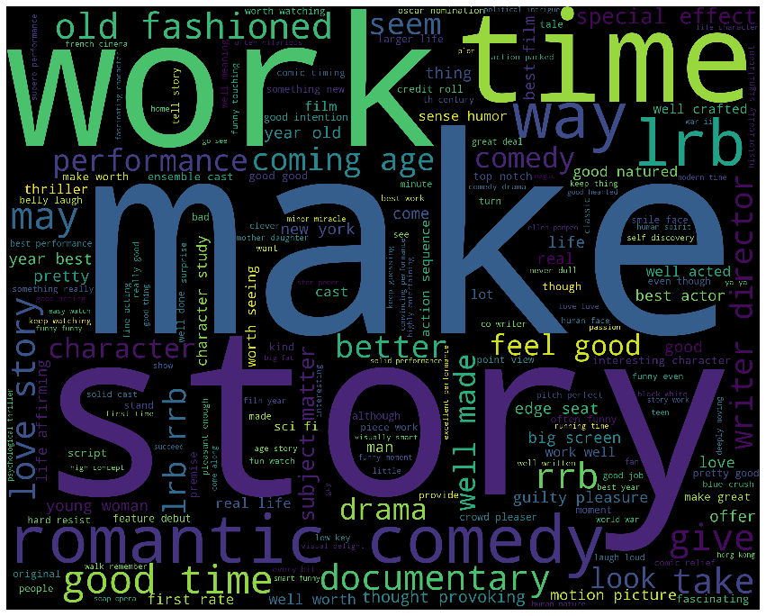

```python
## Visualizing Positive Sentiments reviews:
print("Word Cloud of Positive reviews:")
wordcloud_draw(Token_positive)
```

```
Word Cloud of Neutral reviews:
```

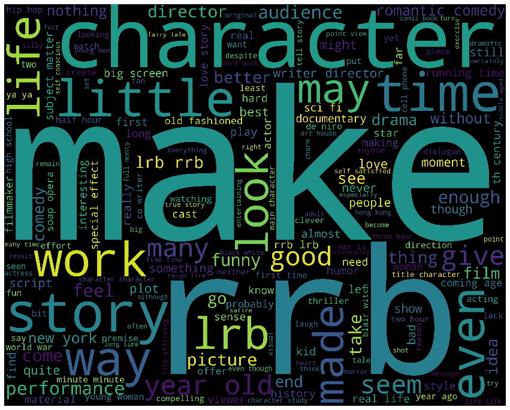

```python
## Visualizing Neutral Sentiments reviews:
print("Word Cloud of Neutral reviews:")
wordcloud_draw(Token_neutral)
```

```
Word Cloud of Negative reviews:
```

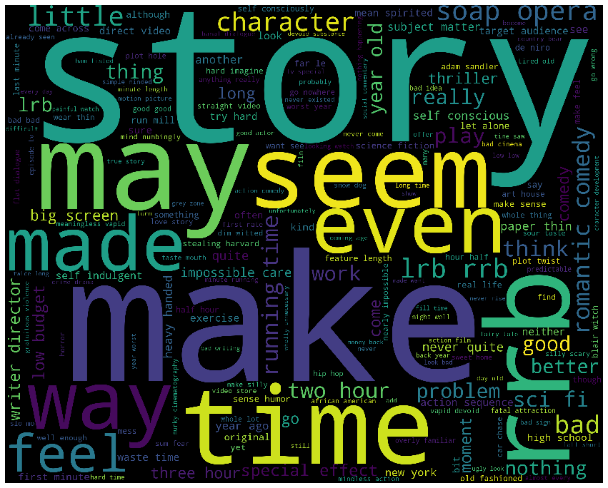

```python
## Visualizing Negative Sentiments reviews:
print("Word Cloud of Negative reviews:")
wordcloud_draw(Token_negative)
```

# Machine Learning Model (with 5 classes)

### Keeping only required columns

```python
col = ['Sentiment', 'Clean_Phrase']
data = data[col]
data = data[pd.notnull(data['Clean_Phrase'])]
#data.columns = ['Sentiment', 'Clean_Phrase']

data.head()
```

|  | Sentiment | Clean_Phrase |
| --- | --- | --- |
| 0 | 1 | escapade demonstrating adage good goose good g... |
| 1 | 2 | escapade demonstrating adage good goose |
| 5 | 2 | escapade demonstrating adage good goose |
| 7 | 2 | escapade demonstrating adage good goose |
| 8 | 2 | escapade |

```python
data.shape
```

```
(152282, 2)
```

### Importing necessary libraries

```python
from sklearn.model_selection import train_test_split
from sklearn.feature_extraction.text import CountVectorizer
from sklearn.feature_extraction.text import TfidfTransformer

from sklearn.naive_bayes import MultinomialNB
from sklearn.linear_model import LogisticRegression
from sklearn.ensemble import RandomForestClassifier, GradientBoostingClassifier
from sklearn.svm import LinearSVC
from sklearn.neighbors import KNeighborsClassifier

from sklearn.model_selection import cross_val_score
from sklearn.metrics import accuracy_score, f1_score, recall_score, precision_score, classification_report
from sklearn.pipeline import Pipeline
```

### Defining the parameters of model

> - Spliting data into train and test set

```python
X = data['Clean_Phrase']
y = data['Sentiment']
```

```python
X_train, X_test, y_train, y_test = train_test_split(X, y, random_state = 42)
```

```python
X_train.shape, X_test.shape, y_train.shape, y_test.shape
```

```
((114211,), (38071,), (114211,), (38071,))
```

## Linear SVM classifier

```python
text_clf_linear_svm = Pipeline([('vect', CountVectorizer()),
                     ('tfidf', TfidfTransformer()),
                     ('clf-linearsvm', LinearSVC()),
])
```

### Fitting the model pipeline on the train data

```python
_ = text_clf_linear_svm.fit(X_train, y_train)
```

### Predicting the sentiment on train data

```python
predicted_linear_svm = text_clf_linear_svm.predict(X_train)
```

### Model evaluation metrics - Accuracy, Precision, Recall, F1 Score

```python
print('Accuracy of Linear SVM is %s' % accuracy_score(predicted_linear_svm, y_train))
print('\nPrecision of Linear SVM is', precision_score(predicted_linear_svm, y_train, average='weighted'))
print('\nRecall of Linear SVM is', recall_score(predicted_linear_svm, y_train,average='weighted'))
print('\nF1 score of Linear SVM is', f1_score(predicted_linear_svm, y_train,average='weighted'))
```

```
Accuracy of Linear SVM is 0.7103694039978636

Precision of Linear SVM is 0.7466655539563283

Recall of Linear SVM is 0.7103694039978636

F1 score of Linear SVM is 0.7216522787916702
```

## Multinomial Naive Bayes classifier

```python
text_clf_MNB = Pipeline([('vect', CountVectorizer()),
                     ('tfidf', TfidfTransformer()),
                     ('clf-MNB', MultinomialNB()),
])
```

### Fitting the model pipeline on the train data

```python
_ = text_clf_MNB.fit(X_train, y_train)
```

### Predicting the sentiment on train data

```python
predicted_MNB = text_clf_MNB.predict(X_train)
```

### Model evaluation metrics - Accuracy, Precision, Recall, F1 Score

```python
print('Accuracy of Multinomial Naive Bayes is %s' % accuracy_score(predicted_MNB, y_train))
print('\nPrecision of Multinomial Naive Bayes is', precision_score(predicted_MNB, y_train, average='weighted'))
print('\nRecall of Multinomial Naive Bayes is', recall_score(predicted_MNB, y_train,average='weighted'))
print('\nF1 score of Multinomial Naive Bayes is', f1_score(predicted_MNB, y_train,average='weighted'))
```

```
Accuracy of Multinomial Naive Bayes is 0.6286960100165483

Precision of Multinomial Naive Bayes is 0.782815555133231

Recall of Multinomial Naive Bayes is 0.6286960100165483

F1 score of Multinomial Naive Bayes is 0.6772874701105506
```

## Logistic Regression classifier

```python
text_clf_LR = Pipeline([('vect', CountVectorizer()),
                     ('tfidf', TfidfTransformer()),
                     ('clf-LR', LogisticRegression()),
])
```

### Fitting the model pipeline on the train data

```python
_ = text_clf_LR.fit(X_train, y_train)
```

### Predicting the sentiment on train data

```python
predicted_LR = text_clf_LR.predict(X_train)
```

### Model evaluation metrics - Accuracy, Precision, Recall, F1 Score

```python
print('Accuracy of Logistic Regression is %s' % accuracy_score(predicted_LR, y_train))
print('\nPrecision of Logistic Regression is', precision_score(predicted_LR, y_train, average='weighted'))
print('\nRecall of Logistic Regression is', recall_score(predicted_LR, y_train,average='weighted'))
print('\nF1 score of Logistic Regression is', f1_score(predicted_LR, y_train,average='weighted'))
```

```
Accuracy of Logistic Regression is 0.6550682508690057

Precision of Logistic Regression is 0.7591886210180149

Recall of Logistic Regression is 0.6550682508690057

F1 score of Logistic Regression is 0.6860707843266961
```

## Random Forest classifier

```python
text_clf_RF = Pipeline([('vect', CountVectorizer()),
                     ('tfidf', TfidfTransformer()),
                     ('clf-RF', RandomForestClassifier()),
])
```

### Fitting the model pipeline on the train data

```python
_ = text_clf_RF.fit(X_train, y_train)
```

### Predicting the sentiment on train data

```python
predicted_RF = text_clf_RF.predict(X_train)
```

### Model evaluation metrics - Accuracy, Precision, Recall, F1 Score

```python
print('Accuracy of Random Forest is %s' % accuracy_score(predicted_RF, y_train))
print('\nPrecision of Random Forest is', precision_score(predicted_RF, y_train, average='weighted'))
print('\nRecall of Random Forest is', recall_score(predicted_RF, y_train,average='weighted'))
print('\nF1 score of Random Forest is', f1_score(predicted_RF, y_train,average='weighted'))
```

```
Accuracy of Random Forest is 0.8551365455166315

Precision of Random Forest is 0.8573896645622735

Recall of Random Forest is 0.8551365455166315

F1 score of Random Forest is 0.8559756171978843
```

## Gradient Boosting Classifier

```python
text_clf_GB = Pipeline([('vect', CountVectorizer()),
                     ('tfidf', TfidfTransformer()),
                     ('clf-GB',GradientBoostingClassifier()),
])
```

### Fitting the model pipeline on the train data

```python
_ = text_clf_GB.fit(X_train, y_train)
```

### Predicting the sentiment on train data

```python
predicted_GB = text_clf_GB.predict(X_train)
```

### Model evaluation metrics - Accuracy, Precision, Recall, F1 Score

```python
print('Accuracy of Gradient Boosting is %s' % accuracy_score(predicted_GB, y_train))
print('\nPrecision of Gradient Boosting is', precision_score(predicted_GB, y_train, average='weighted'))
print('\nRecall of Gradient Boosting is', recall_score(predicted_GB, y_train,average='weighted'))
print('\nF1 score of Gradient Boosting is', f1_score(predicted_GB, y_train,average='weighted'))
```

```
Accuracy of Gradient Boosting is 0.5347383351866283

Precision of Gradient Boosting is 0.9308693640117851

Recall of Gradient Boosting is 0.5347383351866283

F1 score of Gradient Boosting is 0.6549184244381151
```

## Neural Network

```python
from tensorflow.keras.preprocessing.text import Tokenizer                       # Text tokenization utility class
from tensorflow.keras.preprocessing.sequence import pad_sequences               # Pads sequences to the same length
```

> - '`pad_sequences`' transforms a list of sequences (lists of integers) into a 2D Numpy array of shape (num_samples, num_timesteps). num_timesteps is either the maxlen argument if provided, or the length of the longest sequence otherwise.

```python
from tensorflow.keras.models import Model,Sequential
from tensorflow.keras.layers import Dense,Embedding,LSTM,GRU,Dropout,LeakyReLU,Conv1D,MaxPool1D,BatchNormalization
from tensorflow.keras.optimizers import Adam,SGD
from tensorflow.keras.callbacks import ModelCheckpoint
from tensorflow.keras.utils import to_categorical
import tensorflow as tf
```

```python
tokenizer_obj = Tokenizer()
```

> - '`Tokenizer`' allows to vectorize a text corpus, by turning each text into either a sequence of integers (each integer being the index of a token in a dictionary) or into a vector.

```python
tokenizer_obj.fit_on_texts(data['Clean_Phrase'])
```

> - Fitting our input data i.e. Reviews to Tokenizer to get vector of words.

```python
max_lenth = max([len(s.split()) for s in data['Clean_Phrase']])
```

```python
max_lenth
```

```
30
```

> - Setting the Max_lenth to length of review that is of large length among all reviews.

```python
tokenizer_obj.document_count
```

```
152282
```

> - Total number of documents i.e. total reviews present in dataset

```python
len(tokenizer_obj.word_index)
```

```
13600
```

> - Lenth of all the tokens present in entire document.

```python
vocab_size = len(tokenizer_obj.word_index) + 1
```

> - Setting Vocab size which will specify the input size to Neural Network Model.

```python
X_train_tokens = tokenizer_obj.texts_to_sequences(X_train)
X_test_tokens = tokenizer_obj.texts_to_sequences(X_test)
```

> - '`texts_to_sequences`'Converts a text to a sequence of words.

```python
X_train_tokens
```

[output not shown]

[output cut: 1120 more lines]

[output not shown]

```python
X_train_pad = pad_sequences(X_train_tokens,maxlen=max_lenth,padding='post')
X_test_pad = pad_sequences(X_test_tokens,maxlen=max_lenth,padding='post')
```

> - Padding the tokenize data because Neural Network model expect input of same length.

```python
X_train_pad
```

```
array([[12344, 10994,   982, ...,     0,     0,     0],
       [ 2110,  1176,   113, ...,     0,     0,     0],
       [  207,    27,   148, ...,     0,     0,     0],
       ...,
       [  150,  1165,   244, ...,     0,     0,     0],
       [  749,   115,   261, ...,     0,     0,     0],
       [   79,   296,   264, ...,     0,     0,     0]])
```

### Model Building...

```python
EMBEDDING_DIM = 100
```

```python
model = Sequential()
```

```python
model.add(Embedding(vocab_size,EMBEDDING_DIM,input_length=max_lenth))
```

```python
model.add(LSTM(256,dropout=0.30, recurrent_dropout=0.30,return_sequences=True))
model.add(LSTM(128,dropout=0.30, recurrent_dropout=0.30,return_sequences=False))
model.add(BatchNormalization())
model.add(Dense(512,activation='relu'))
model.add(Dropout(0.2))
model.add(BatchNormalization())
model.add(Dense(256,activation='relu'))
model.add(Dropout(0.2))
model.add(Dense(5,activation='softmax'))
```

```python
model.compile(loss='categorical_crossentropy',optimizer='adam',metrics=['accuracy'])
```

```python
model.summary()
```

```
Model: "sequential"
_________________________________________________________________
Layer (type)                 Output Shape              Param #
=================================================================
embedding (Embedding)        (None, 30, 100)           1360100
_________________________________________________________________
lstm (LSTM)                  (None, 30, 256)           365568
_________________________________________________________________
lstm_1 (LSTM)                (None, 128)               197120
_________________________________________________________________
batch_normalization (BatchNo (None, 128)               512
_________________________________________________________________
dense (Dense)                (None, 512)               66048
_________________________________________________________________
dropout (Dropout)            (None, 512)               0
_________________________________________________________________
batch_normalization_1 (Batch (None, 512)               2048
_________________________________________________________________
dense_1 (Dense)              (None, 256)               131328
_________________________________________________________________
dropout_1 (Dropout)          (None, 256)               0
_________________________________________________________________
dense_2 (Dense)              (None, 5)                 1285
=================================================================
Total params: 2,124,009
Trainable params: 2,122,729
Non-trainable params: 1,280
_________________________________________________________________
```

```python
y_train_cat = to_categorical(y_train, num_classes=5, dtype='float32')
y_test_cat  = to_categorical(y_test, num_classes=5, dtype='float32')
```

```python
model.fit(X_train_pad,y_train_cat,batch_size=512,epochs=6,validation_data=(X_test_pad,y_test_cat),verbose=1)
```

```
Train on 114211 samples, validate on 38071 samples
```

```
<tensorflow.python.keras.callbacks.History at 0x1ec8a842208>
```

```python
model.compile(loss='categorical_crossentropy',optimizer=Adam(learning_rate=0.0001),metrics=['accuracy'])
```

```python
model.fit(X_train_pad,y_train_cat,batch_size=512,epochs=6,validation_data=(X_test_pad,y_test_cat),verbose=1)
```

```
Train on 114211 samples, validate on 38071 samples
```

```
<tensorflow.python.keras.callbacks.History at 0x1ec8d2189c8>
```

```python
#model.save('NN_model_to_Sentiment_Analysis.h5')
```

```python
#from tensorflow.keras.models import load_model
#model = load_model('/content/NN_model_to_Sentiment_Analysis.h5')
```

### Predicting the sentiment on train data

```python
pred_nn = np.argmax(model.predict(X_train_pad),axis = 1)
```

### Model evaluation metrics - Accuracy, Precision, Recall, F1 Score

```python
print('Accuracy of NN model is %s' % accuracy_score(pred_nn, y_train))
print('\nPrecision of NN model is', precision_score(pred_nn, y_train, average='weighted'))
print('\nRecall of NN model is', recall_score(pred_nn, y_train,average='weighted'))
print('\nF1 score of NN model is', f1_score(pred_nn, y_train,average='weighted'))
```

```
Accuracy of NN model is 0.7189237463992085

Precision of NN model is 0.7326973564185294

Recall of NN model is 0.7189237463992085

F1 score of NN model is 0.7235180628618323
```

## Comparing Model Performance using Classification Parameters

```python
sentiment_model = {
    'Linear SVM': [accuracy_score(predicted_linear_svm, y_train),
                   precision_score(predicted_linear_svm, y_train, average='weighted'),
                   recall_score(predicted_linear_svm, y_train,average='weighted'),
                   f1_score(predicted_linear_svm, y_train,average='weighted')],
    'Multinomial NB': [accuracy_score(predicted_MNB, y_train),
                       precision_score(predicted_MNB, y_train, average='weighted'),
                       recall_score(predicted_MNB, y_train,average='weighted'),
                       f1_score(predicted_MNB, y_train,average='weighted')],
    'Logistic Regression': [accuracy_score(predicted_LR, y_train),
                            precision_score(predicted_LR, y_train, average='weighted'),
                            recall_score(predicted_LR, y_train,average='weighted'),
                            f1_score(predicted_LR, y_train,average='weighted')],
    'Random Forest': [accuracy_score(predicted_RF, y_train),
                      precision_score(predicted_RF, y_train, average='weighted'),
                      recall_score(predicted_RF, y_train,average='weighted'),
                      f1_score(predicted_RF, y_train,average='weighted')],
    'Gradient Boosting': [accuracy_score(predicted_GB, y_train),
                      precision_score(predicted_GB, y_train, average='weighted'),
                      recall_score(predicted_GB, y_train,average='weighted'),
                      f1_score(predicted_GB, y_train,average='weighted')],
    'Neural Network': [accuracy_score(pred_nn, y_train),
                      precision_score(pred_nn, y_train, average='weighted'),
                      recall_score(pred_nn, y_train,average='weighted'),
                      f1_score(pred_nn, y_train,average='weighted')]

}
```

```python
sentiment_model_df = pd.DataFrame(sentiment_model, index=['Accuracy', 'Precision', 'Recall', 'F1-Score'])

sentiment_model_df
```

|  | Linear SVM | Multinomial NB | Logistic Regression | Random Forest | Gradient Boosting | Neural Network |
| --- | --- | --- | --- | --- | --- | --- |
| Accuracy | 0.710369 | 0.628696 | 0.655068 | 0.855137 | 0.534738 | 0.718924 |
| Precision | 0.746666 | 0.782816 | 0.759189 | 0.857390 | 0.930869 | 0.732697 |
| Recall | 0.710369 | 0.628696 | 0.655068 | 0.855137 | 0.534738 | 0.718924 |
| F1-Score | 0.721652 | 0.677287 | 0.686071 | 0.855976 | 0.654918 | 0.723518 |

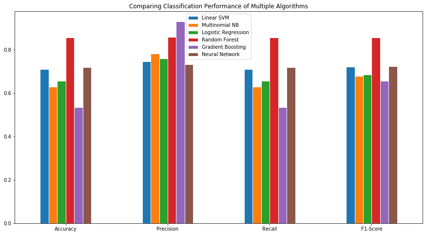

```python
# Visualizing the various performance parameters

plt.rcParams["figure.figsize"] = (15,8)

sentiment_model_df.plot.bar(edgecolor = "white")
plt.legend().set_visible(True)
plt.title("Comparing Classification Performance of Multiple Algorithms")
plt.xticks(rotation = 0)
plt.show()
```

# Cross-Validation for Random Forest Machine Learning Model

```python
from sklearn.model_selection import cross_val_score
```

```python
CV_accuracy_RF = cross_val_score(text_clf_RF, X_train, y_train, cv=5,scoring="accuracy")
print("Average Accuracy Random Forest: %0.2f (+/- %0.2f)" % (CV_accuracy_RF.mean(), CV_accuracy_RF.std() * 2))
```

```
Average Accuracy Random Forest: 0.62 (+/- 0.00)
```

```python
CV_f1scores_RF = cross_val_score(text_clf_RF, X_train, y_train, cv=5,scoring="f1_micro")
print("Average F1 Score Random Forest: %0.2f (+/- %0.2f)" % (CV_f1scores_RF.mean(), CV_f1scores_RF.std() * 2))
```

```
Average F1 Score Random Forest: 0.62 (+/- 0.00)
```

## The performance of Random Forest is consistent with respect to Accuracy and F1 Score (function of Precision and Recall), hence, we can conclude that the machine learning model of Random Forest would provide a robust performance.

# Predicting the sentiments on Test data using Random Forest Model

```python
predicted_RF = text_clf_RF.predict(X_test)
```

## Model evaluation on Test Data - Accuracy, Precision, Recall, F1 Score

### Individual Class Level Performance

```python
print(classification_report(y_test, predicted_RF))
```

```
              precision    recall  f1-score   support

           0       0.47      0.40      0.43      1791
           1       0.52      0.48      0.50      6796
           2       0.71      0.77      0.74     19048
           3       0.54      0.51      0.52      8147
           4       0.48      0.40      0.44      2289

    accuracy                           0.62     38071
   macro avg       0.54      0.51      0.53     38071
weighted avg       0.62      0.62      0.62     38071
```

### Overall Level Performance

```python
print('Accuracy of Random Forest is %s' % accuracy_score(predicted_RF, y_test))
print('\nPrecision of Random Forest is', precision_score(predicted_RF, y_test, average='weighted'))
print('\nRecall of Random Forest is', recall_score(predicted_RF, y_test,average='weighted'))
print('\nF1 score of Random Forest is', f1_score(predicted_RF, y_test,average='weighted'))
```

```
Accuracy of Random Forest is 0.624386015602427

Precision of Random Forest is 0.6378295603807169

Recall of Random Forest is 0.624386015602427

F1 score of Random Forest is 0.6299340809392676
```